# Advanced Regression - House Price Prediction

## Lasso regression model:

```python
# Checking the dimension of X_train & y_train
print("X_train:", X_train.shape)
print("y_train:", y_train.shape)
```

```
X_train: (974, 100)
y_train: (974,)
```

```python
lm = Lasso(alpha=0.001)
lm.fit(X_train,y_train)
```

```
Lasso(alpha=0.001)
```

```python
y_train_pred = lm.predict(X_train)
print(f'R2 Score on train data: {r2_score(y_true=y_train,y_pred=y_train_pred)}')
```

```
R2 Score on train data: 0.9164237500130973
```

```python
y_test_pred  = lm.predict(X_test)
print(f'R2 Score on test data: {r2_score(y_true=y_test,y_pred=y_test_pred)}')
```

```
R2 Score on test data: 0.902881184127591
```

```python
model_parameter = list(lm.coef_)
model_parameter.insert(0,lm.intercept_)
model_parameter = [round(x,3) for x in model_parameter]
col = df_train.columns
col.insert(0,'Constant')
list(zip(col,model_parameter))
```

```
[('MSSubClass', -0.85),
 ('LotFrontage', -0.086),
 ('LotArea', 0.23),
 ('LotShape', 0.149),
 ('LandSlope', 0.117),
 ('OverallQual', 0.034),
 ('OverallCond', -0.0),
 ('MasVnrArea', 0.111),
 ('ExterQual', 0.0),
 ('ExterCond', 0.0),
 ('BsmtQual', -0.004),
 ('BsmtCond', 0.339),
 ('BsmtExposure', 0.106),
 ('BsmtFinType1', 0.0),
 ('BsmtFinSF1', -0.172),
 ('BsmtFinType2', 0.689),
 ('BsmtFinSF2', 0.443),
 ('BsmtUnfSF', 0.595),
 ('TotalBsmtSF', 0.429),
 ('HeatingQC', 0.055),
 ('1stFlrSF', 0.159),
 ('2ndFlrSF', -0.038),
 ('LowQualFinSF', -0.0),
 ('GrLivArea', -0.0),
 ('BsmtFullBath', -0.025),
 ('BsmtHalfBath', 0.253),
 ('FullBath', -0.139),
 ('HalfBath', -0.206),
 ('BedroomAbvGr', 0.191),
 ('KitchenAbvGr', -0.028),
 ('KitchenQual', 0.266),
 ('TotRmsAbvGrd', 0.174),
 ('Fireplaces', 0.126),
 ('GarageFinish', -0.0),
 ('GarageArea', -0.0),
 ('GarageQual', 0.047),
 ('GarageCond', 0.0),
 ('WoodDeckSF', 0.045),
 ('OpenPorchSF', 0.0),
 ('EnclosedPorch', -1.664),
```

[output cut: 46 more lines]

```
 ('Condition1_RRAe', -0.088),
 ('Condition1_RRAn', 0.046),
 ('Condition1_RRNe', 0.0),
 ('Condition1_RRNn', 0.0),
 ('Condition2_Feedr', -0.0),
 ('Condition2_Norm', 0.0),
 ('Condition2_PosA', -0.039),
 ('Condition2_PosN', -0.017),
 ('Condition2_RRAn', 0.0),
 ('Condition2_RRNn', 0.0),
 ('BldgType_2fmCon', 0.0),
 ('BldgType_Duplex', 0.114),
 ('BldgType_Twnhs', 0.0),
 ('BldgType_TwnhsE', -0.153),
 ('HouseStyle_1.5Unf', -0.162)]
```

**Apply `GridSearchCV`, to improve the model with the optimal value of `alpha`:**

```python
folds = KFold(n_splits=10, shuffle=True, random_state=42)

hyper_param = {'alpha':[0.0001, 0.001, 0.01, 0.05, 0.1,
 0.2, 0.3, 0.4, 0.5, 0.6, 0.7, 0.8, 0.9, 1.0, 2.0, 3.0,
 4.0, 5.0, 6.0, 7.0, 8.0, 9.0, 10.0, 20, 50, 100, 500, 1000]}

model = Lasso()

model_cv = GridSearchCV(estimator = model,
                        param_grid=hyper_param,
                        scoring='r2',
                        cv=folds,
                        verbose=1,
                        return_train_score=True
                       )

model_cv.fit(X_train,y_train)
```

```
Fitting 10 folds for each of 28 candidates, totalling 280 fits
```

```
GridSearchCV(cv=KFold(n_splits=10, random_state=42, shuffle=True),
             estimator=Lasso(),
             param_grid={'alpha': [0.0001, 0.001, 0.01, 0.05, 0.1, 0.2, 0.3,
                                   0.4, 0.5, 0.6, 0.7, 0.8, 0.9, 1.0, 2.0, 3.0,
                                   4.0, 5.0, 6.0, 7.0, 8.0, 9.0, 10.0, 20, 50,
                                   100, 500, 1000]},
             return_train_score=True, scoring='r2', verbose=1)
```

```python
cv_result_l = pd.DataFrame(model_cv.cv_results_)
cv_result_l['param_alpha'] = cv_result_l['param_alpha'].astype('float32')
cv_result_l.head()
```

|  | mean_fit_time | std_fit_time | mean_score_time | std_score_time | param_alpha | params | split0_test_score | split1_test_score | split2_test_score | split3_test_score | ... | split2_train_score | split3_train_score | split4_train_score | split5_train_score | split6_train_score | split7_train_score | split8_train_score | split9_train_score | mean_train_score | std_train_score |
| --- | --- | --- | --- | --- | --- | --- | --- | --- | --- | --- | --- | --- | --- | --- | --- | --- | --- | --- | --- | --- | --- |
| 0 | 0.049196 | 0.008295 | 0.005599 | 0.001356 | 0.0001 | {'alpha': 0.0001} | 0.901358 | 0.876882 | 0.918987 | 0.784444 | ... | 0.927840 | 0.936100 | 0.928391 | 0.926508 | 0.930174 | 0.930934 | 0.931599 | 0.933960 | 0.930288 | 0.002864 |
| 1 | 0.054101 | 0.004460 | 0.004898 | 0.000700 | 0.0010 | {'alpha': 0.001} | 0.912171 | 0.816964 | 0.925902 | 0.835304 | ... | 0.915793 | 0.923526 | 0.915779 | 0.914323 | 0.919145 | 0.919336 | 0.919754 | 0.923109 | 0.918733 | 0.002928 |
| 2 | 0.013299 | 0.001845 | 0.004701 | 0.000641 | 0.0100 | {'alpha': 0.01} | 0.887839 | 0.785039 | 0.917347 | 0.893431 | ... | 0.873473 | 0.876457 | 0.872525 | 0.875662 | 0.878512 | 0.877340 | 0.879590 | 0.894690 | 0.879219 | 0.006472 |
| 3 | 0.010999 | 0.002000 | 0.005800 | 0.000748 | 0.0500 | {'alpha': 0.05} | 0.845241 | 0.751866 | 0.891312 | 0.871825 | ... | 0.843164 | 0.845185 | 0.840526 | 0.844605 | 0.849225 | 0.848394 | 0.848424 | 0.865817 | 0.849252 | 0.007173 |
| 4 | 0.011800 | 0.001078 | 0.006099 | 0.000830 | 0.1000 | {'alpha': 0.1} | 0.799307 | 0.711999 | 0.849558 | 0.822620 | ... | 0.807201 | 0.808556 | 0.804836 | 0.808962 | 0.815118 | 0.812208 | 0.812499 | 0.829544 | 0.813491 | 0.007024 |

5 rows × 31 columns

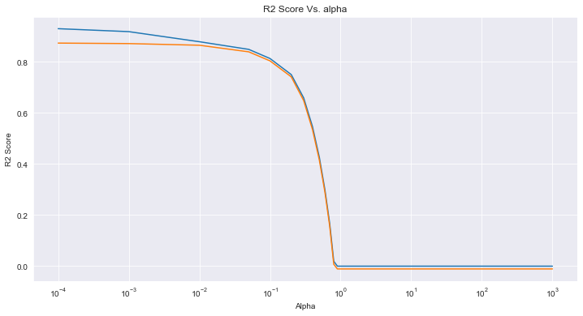

```python
plt.figure(figsize=(12,6))
plt.plot(cv_result_l['param_alpha'],cv_result_l['mean_train_score'])
plt.plot(cv_result_l['param_alpha'],cv_result_l['mean_test_score'])
plt.xscale('log')
plt.ylabel('R2 Score')
plt.xlabel('Alpha')
plt.title("R2 Score Vs. alpha")
plt.show()
```

```python
# Check the best parameter (Alpha value)
model_cv.best_params_
```

```
{'alpha': 0.0001}
```

Build the model based on the best aplha:

```python
lasso = Lasso(alpha=0.0001)
lasso.fit(X_train,y_train)

y_train_pred = lasso.predict(X_train)
y_test_pred = lasso.predict(X_test)

print(f'R2 Score on train data: {r2_score(y_true=y_train,y_pred=y_train_pred)}')
print(f'R2 Score on test data: {r2_score(y_true=y_test,y_pred=y_test_pred)}')
```

```
R2 Score on train data: 0.9284475772328702
R2 Score on test data: 0.8955562004366666
```

```python
model_param = list(lasso.coef_)
model_param.insert(0,lasso.intercept_)
cols = df_train.columns
cols.insert(0,'const')
lasso_coef = pd.DataFrame(list(zip(cols,model_param)))
lasso_coef.columns = ['Featuere','Coef']
```

```python
lasso_coef.sort_values(by='Coef',ascending=False).head(10)
```

|  | Featuere | Coef |
| --- | --- | --- |
| 15 | BsmtFinType2 | 1.305615 |
| 17 | BsmtUnfSF | 1.172931 |
| 16 | BsmtFinSF2 | 1.088577 |
| 18 | TotalBsmtSF | 1.069399 |
| 38 | OpenPorchSF | 0.576761 |
| 98 | BldgType_Twnhs | 0.355093 |
| 40 | 3SsnPorch | 0.350419 |
| 30 | KitchenQual | 0.334908 |
| 31 | TotRmsAbvGrd | 0.327525 |
| 94 | Condition2_RRAn | 0.321742 |

**Lasso Regression:**

> - R2 Score on train data: 0.9284475772328702
> - R2 Score on test data: 0.8955562004366666

## Ridge Regression:

```python
ridge = Ridge(alpha=0.001)
ridge.fit(X_train,y_train)

y_train_pred = ridge.predict(X_train)
print(f'R2 Score on train data: {r2_score(y_train,y_train_pred)}')
y_test_pred = ridge.predict(X_test)
print(f'R2 Score on test data: {r2_score(y_test,y_test_pred)}')
```

```
R2 Score on train data: 0.9290793018311567
R2 Score on test data: 0.8903146007152193
```

As we can see the above alpha value is not optimal for ridge there are sign of overfitting the clear difference we can see in the train and test score

**Apply `GridSearchCV`, to improve the model with the optimal value of `alpha`:**

```python
folds  = KFold(n_splits=10,shuffle=True,random_state=42)

hyper_param = {'alpha':[0.0001, 0.001, 0.01, 0.05, 0.1,
 0.2, 0.3, 0.4, 0.5, 0.6, 0.7, 0.8, 0.9, 1.0, 2.0, 3.0,
 4.0, 5.0, 6.0, 7.0, 8.0, 9.0, 10.0, 20, 50, 100, 500, 1000 ]}

model = Ridge()

model_cv = GridSearchCV(estimator=model,
                        param_grid=hyper_param,
                        scoring='r2',
                        cv=folds,
                        verbose=1,
                        return_train_score=True)

model_cv.fit(X_train,y_train)
```

```
Fitting 10 folds for each of 28 candidates, totalling 280 fits
```

```
GridSearchCV(cv=KFold(n_splits=10, random_state=42, shuffle=True),
             estimator=Ridge(),
             param_grid={'alpha': [0.0001, 0.001, 0.01, 0.05, 0.1, 0.2, 0.3,
                                   0.4, 0.5, 0.6, 0.7, 0.8, 0.9, 1.0, 2.0, 3.0,
                                   4.0, 5.0, 6.0, 7.0, 8.0, 9.0, 10.0, 20, 50,
                                   100, 500, 1000]},
             return_train_score=True, scoring='r2', verbose=1)
```

```python
cv_result_r = pd.DataFrame(model_cv.cv_results_)
cv_result_r['param_alpha'] = cv_result_r['param_alpha'].astype('float32')
cv_result_r.head()
```

|  | mean_fit_time | std_fit_time | mean_score_time | std_score_time | param_alpha | params | split0_test_score | split1_test_score | split2_test_score | split3_test_score | ... | split2_train_score | split3_train_score | split4_train_score | split5_train_score | split6_train_score | split7_train_score | split8_train_score | split9_train_score | mean_train_score | std_train_score |
| --- | --- | --- | --- | --- | --- | --- | --- | --- | --- | --- | --- | --- | --- | --- | --- | --- | --- | --- | --- | --- | --- |
| 0 | 0.011497 | 0.002204 | 0.007095 | 0.001041 | 0.0001 | {'alpha': 0.0001} | 0.899773 | 0.887191 | 0.912978 | 0.776935 | ... | 0.928421 | 0.936740 | 0.929104 | 0.927128 | 0.930714 | 0.931581 | 0.932260 | 0.934622 | 0.930912 | 0.002881 |
| 1 | 0.009901 | 0.002982 | 0.005799 | 0.001166 | 0.0010 | {'alpha': 0.001} | 0.899775 | 0.887139 | 0.913080 | 0.777244 | ... | 0.928421 | 0.936740 | 0.929104 | 0.927128 | 0.930714 | 0.931580 | 0.932260 | 0.934622 | 0.930912 | 0.002881 |
| 2 | 0.007701 | 0.000640 | 0.004499 | 0.000671 | 0.0100 | {'alpha': 0.01} | 0.899808 | 0.886617 | 0.914057 | 0.780271 | ... | 0.928417 | 0.936735 | 0.929101 | 0.927125 | 0.930711 | 0.931578 | 0.932257 | 0.934618 | 0.930909 | 0.002881 |
| 3 | 0.010800 | 0.002521 | 0.006399 | 0.001744 | 0.0500 | {'alpha': 0.05} | 0.899991 | 0.884280 | 0.917561 | 0.792482 | ... | 0.928349 | 0.936631 | 0.929036 | 0.927064 | 0.930660 | 0.931518 | 0.932188 | 0.934545 | 0.930845 | 0.002869 |
| 4 | 0.008701 | 0.001793 | 0.004899 | 0.000943 | 0.1000 | {'alpha': 0.1} | 0.900273 | 0.881409 | 0.920666 | 0.805365 | ... | 0.928179 | 0.936368 | 0.928874 | 0.926910 | 0.930537 | 0.931368 | 0.932020 | 0.934394 | 0.930687 | 0.002843 |

5 rows × 31 columns

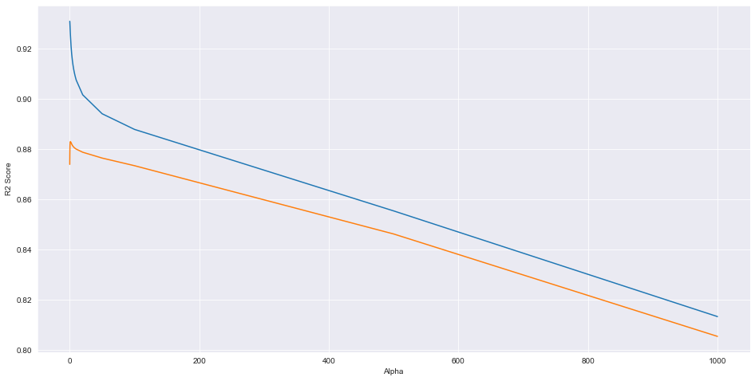

```python
plt.figure(figsize=(16,8))
plt.plot(cv_result_r['param_alpha'],cv_result_r['mean_train_score'])
plt.plot(cv_result_r['param_alpha'],cv_result_r['mean_test_score'])
plt.xlabel('Alpha')
# plt.xscale('log')
plt.ylabel('R2 Score')
plt.show()
```

```python
# Checking the best parameter(Alpha value)
model_cv.best_params_
```

```
{'alpha': 1.0}
```

Build the model based on the best aplha:

```python
ridge = Ridge(alpha = 1)
ridge.fit(X_train,y_train)

y_pred_train = ridge.predict(X_train)
print(f'R2 Score on train data: {r2_score(y_train,y_pred_train)}')

y_pred_test = ridge.predict(X_test)
print(f'R2 Score on test data: {r2_score(y_test,y_pred_test)}')
```

```
R2 Score on train data: 0.9244015745286842
R2 Score on test data: 0.8972460011368416
```

```python
model_parameter = list(ridge.coef_)
model_parameter.insert(0,ridge.intercept_)
cols = df_train.columns
cols.insert(0,'constant')
ridge_coef = pd.DataFrame(list(zip(cols,model_parameter)))
ridge_coef.columns = ['Feaure','Coef']
```

```python
ridge_coef.sort_values(by='Coef',ascending=False).head(10)
```

|  | Feaure | Coef |
| --- | --- | --- |
| 15 | BsmtFinType2 | 0.879244 |
| 17 | BsmtUnfSF | 0.777305 |
| 18 | TotalBsmtSF | 0.662514 |
| 16 | BsmtFinSF2 | 0.650679 |
| 38 | OpenPorchSF | 0.361002 |
| 30 | KitchenQual | 0.330103 |
| 40 | 3SsnPorch | 0.298646 |
| 31 | TotRmsAbvGrd | 0.273778 |
| 25 | BsmtHalfBath | 0.266133 |
| 98 | BldgType_Twnhs | 0.265354 |

## `Model selection`:

**Lasso Regression:**

> - R2 Score on train data: 0.9284475772328702
> - R2 Score on test data: 0.8955562004366666
> - alpha: 0.0001

> It is evident that the R2 scores are similar for both Lasso and Ridge regression. However, as Lasso regression penalize more on the dataset, inturn helping in more feature elimination, we will conider **Lasso Regression model as the final model**.

## `Final model`:

```python
lasso = Lasso(alpha=0.0001)
lasso.fit(X_train,y_train)

y_train_pred = lasso.predict(X_train)
y_test_pred = lasso.predict(X_test)

print(f'R2 Score on train data: {r2_score(y_true=y_train,y_pred=y_train_pred)}')
print(f'R2 Score on train data: {r2_score(y_true=y_test,y_pred=y_test_pred)}')
```

```
R2 Score on train data: 0.9284475772328702
R2 Score on train data: 0.8955562004366666
```

```python
model_param = list(lasso.coef_)
model_param.insert(0,lasso.intercept_)
cols = df_train.columns
cols.insert(0,'const')
lasso_coef = pd.DataFrame(list(zip(cols,model_param)))
lasso_coef.columns = ['Featuere','Coef']
lasso_coef.sort_values(by='Coef',ascending=False).head(10)
```

|  | Featuere | Coef |
| --- | --- | --- |
| 15 | BsmtFinType2 | 1.305615 |
| 17 | BsmtUnfSF | 1.172931 |
| 16 | BsmtFinSF2 | 1.088577 |
| 18 | TotalBsmtSF | 1.069399 |
| 38 | OpenPorchSF | 0.576761 |
| 98 | BldgType_Twnhs | 0.355093 |
| 40 | 3SsnPorch | 0.350419 |
| 30 | KitchenQual | 0.334908 |
| 31 | TotRmsAbvGrd | 0.327525 |
| 94 | Condition2_RRAn | 0.321742 |

```
Log(Y) = C + 1.305615(x1) + 1.172931(x2) + 1.088577(x3) + 1.069399(x4) + 0.576761(x5) + 0.355093(x6) + 0.350419(x7) + 0.334908(x8) + 0.327525(x9) + 0.321742(x10) + Error term(RSS + alpha * (sum of absolute value of coefficients))
```

> Inference: Keep a check on these predictors affecting the price of the house.
> - The higher values of positive coeeficients suggest a high sale value.
> - The higher values of negative coeeficients suggest a decrease in sale value.
> - So, when the market value of the property is lower than the Predicted Sale Price, its the time to buy.

# `Assessment Questions`

**1. Explain how you would handle missing data in a given dataset and provide a code snippet demonstrating this.**

Imputing the data (fill missing values) using mean,median and other static value will introduce bias in the model and alter the distribution of the data in the variable. Hence using advanced data imputation models like Iterative imputation which leverages all other variables in the data to predic the missing value in the entry will be a better option and have less impact in its distribution. Refer the **data imputation section** in this analysis and observe how it does not effect the **distribution of data** in this analysis.

**2. Prepare a high-level lesson plan for an introductory session on deep learning.**

Deep Learning is to be learned using mathematical representations starting from Neural Networks sliding into CNN, RNN and Deep Learning networks.

**3. How would you troubleshoot a machine learning model whose performance isn't as expected? Discuss your approach briefly.**

Poor performance generally refers to poor data. Identify the statistical significance of the data, perform the data quality check, data wrangling and cleaning process, transform the data, standardize the data and identify the best hyperparameters.

**4. Explain in simple terms what Natural Language Processing (NLP) is and its real-world applications.**

Natural Language Processing (NLP) refer to conversion of natural language text into machine understandable format for further processing and understanding the user input and requirement. It has wide range of applications. For example it can be used to idenfity the sentiment analysis in product reviews, customer feedbacks and blogs. It is already playing a significant role in auto correction feature imbuded into the mobile phones and various platforms.

**5. Write a SQL query to retrieve specific information from a relational database. The schema will be provided**

A connection can be established between python platform and SQL database using the `SQLAlchemy` library. Then the query can be executed just as in any SQL platforms like `SQLite` or `DBeaver` from the `Jupyter Notebook` or `VScode editor` based on the requirement.

## Credits:

> - Vamsi Krishna P
> - vamshi.krishna.prime@gmail.com

|

|

# End of Notebook

|

|